# STAT 540 Seminar 06: Fitting and interpreting linear models (high volume)

## STAT 540 Seminar 06: Fitting and interpreting linear models (high volume)

### Hao Chen

**2014-02-28**

- Repeat the examples in the seminar
- Take-home exercise

> The R markdown file can be found on my [Github](https://github.com/nelsonch/stat540-2014-chen-hao/blob/master/seminar%2006/seminar06.Rmd).

The following data files will be used in this seminar:

- GSE4051_data.tsv: full data matrix
- GSE4051_design.rds: experimental design

Load these data files:

```r
> prDat <- read.table("GSE4051_data.tsv")
> str(prDat, list.len = 5)
```

```
'data.frame':   29949 obs. of  39 variables:
 $ Sample_20: num  7.24 9.48 10.01 8.36 8.59 ...
 $ Sample_21: num  7.41 10.02 10.04 8.37 8.62 ...
 $ Sample_22: num  7.17 9.85 9.91 8.4 8.52 ...
 $ Sample_23: num  7.07 10.13 9.91 8.49 8.64 ...
 $ Sample_16: num  7.38 7.64 8.42 8.36 8.51 ...
  [list output truncated]
```

```r
> prDes <- readRDS("GSE4051_design.rds")
> str(prDes)
```

```
'data.frame':   39 obs. of  4 variables:
 $ sidChar : chr  "Sample_20" "Sample_21" "Sample_22" "Sample_23" ...
 $ sidNum  : num  20 21 22 23 16 17 6 24 25 26 ...
 $ devStage: Factor w/ 5 levels "E16","P2","P6",..: 1 1 1 1 1 1 1 2 2 2 ...
 $ gType   : Factor w/ 2 levels "wt","NrlKO": 1 1 1 1 2 2 2 1 1 1 ...
```

Load required R packages:

```r
> library(limma)
> library(lattice)
```

User-written functions:

- `prepareData`: extract excerpts from the data files.
- `stripplotIt`: stripplot excerpts from the data files.

### Repeat the examples in the seminar

#### Fit a linear model: explain gene expression in the wild type mice as a function of developmental stage (one-way ANOVA)

```r
> wtDes <- subset(prDes, gType == "wt")
> str(wtDes)
```

```
'data.frame':   20 obs. of  4 variables:
 $ sidChar : chr  "Sample_20" "Sample_21" "Sample_22" "Sample_23" ...
 $ sidNum  : num  20 21 22 23 24 25 26 27 28 29 ...
 $ devStage: Factor w/ 5 levels "E16","P2","P6",..: 1 1 1 1 2 2 2 2 3 3 ...
 $ gType   : Factor w/ 2 levels "wt","NrlKO": 1 1 1 1 1 1 1 1 1 1 ...
```

```r
> wtDat <- subset(prDat, select = prDes$gType == "wt")
> str(wtDat, list.len = 5)
```

```
'data.frame':   29949 obs. of  20 variables:
 $ Sample_20: num  7.24 9.48 10.01 8.36 8.59 ...
 $ Sample_21: num  7.41 10.02 10.04 8.37 8.62 ...
 $ Sample_22: num  7.17 9.85 9.91 8.4 8.52 ...
 $ Sample_23: num  7.07 10.13 9.91 8.49 8.64 ...
 $ Sample_24: num  7.11 9.75 9.39 8.37 8.36 ...
  [list output truncated]
```

Fit the model with `limma`.

```r
> wtDesMat <- model.matrix(~devStage, wtDes)
> wtFit <- lmFit(wtDat, wtDesMat)
> wtEbFit <- eBayes(wtFit)
```

For each probe, test if it has differential expression across the five devStages.

```r
> (dsHits <- topTable(wtEbFit, coef = grep("devStage", colnames(coef(wtEbFit)))))
```

```
             devStageP2 devStageP6 devStageP10 devStage4_weeks AveExpr
1440645_at       0.3990     0.1952      0.9200           3.961   6.528
1416041_at       0.1580     0.4797      0.3327           5.115   9.383
1425222_x_at     0.8820     0.7995      1.5488           5.532   7.028
1451635_at       1.3025     1.1900      2.0160           6.188   8.319
1429028_at      -2.4433    -3.4073     -4.3105          -4.602   8.045
1422929_s_at    -2.9117    -3.6182     -3.5472          -3.661   7.278
1424852_at       0.4575     0.2298      0.5740           3.979   7.454
1425171_at       0.9980     3.0530      5.2787           6.079   9.620
1451617_at       0.7255     2.5128      4.9837           6.685   8.817
1451618_at       0.6028     2.8903      5.0507           6.288   9.431
                 F   P.Value adj.P.Val
1440645_at   425.4 1.588e-17 4.755e-13
1416041_at   195.5 1.522e-14 2.280e-10
1425222_x_at 173.4 4.348e-14 4.341e-10
1451635_at   157.3 1.013e-13 7.585e-10
1429028_at   148.8 1.646e-13 9.203e-10
1422929_s_at 146.9 1.844e-13 9.203e-10
1424852_at   143.2 2.290e-13 9.799e-10
1425171_at   138.8 3.002e-13 1.124e-09
1451617_at   136.5 3.485e-13 1.160e-09
1451618_at   134.2 4.032e-13 1.207e-09
```

Extracting and plotting data to produce a plot for hits 3, 6, and 9 on the list.

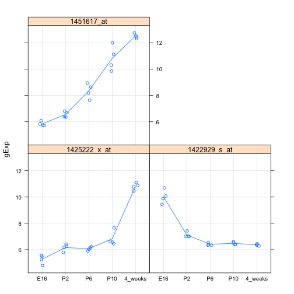

```r
> stripplotIt(prepareData(rownames(dsHits)[c(3, 6, 9)]))
```

#### Be the boss of `topTable()`

How many probes have Benjamini-Hochberg (“BH”) adjusted p-values for the F test conducted above that are less than 1e-05?

> Note that the default adjustment method for `topTable()` fcuntion is “BH” adjustment method, and the `p.value` argument in the `topTable()` refers to the adjusted p-value, not the raw p-value.

```r
> cutoff <- 1e-05
> dsHits <- topTable(wtEbFit, coef = grep("devStage", colnames(coef(wtEbFit))),
+                    p.value = cutoff, n = Inf)
> n <- nrow(dsHits)
```

Answer: 350 probes.

What is the 63rd hit on this list? Provide it's Affy ID, F statistic, BH adjusted p-value, and the estimated effect for developmental stage “P6” in that order.

```r
> dsHits[63, c("F", "adj.P.Val", "devStageP6")]
```

```
                 F adj.P.Val devStageP6
1451633_a_at 64.01 1.049e-07      2.069
```

Consider the effects associated with developmental stages P2 and P10. Scatterplot the t statistics for the test that the P2 effect is zero against that for P10.

> `"sort = none"` arugment in the `topTable()` function will display the probes in the orginal order, and `"n = Inf"` will return all the probes.

```r
> P2Hits <- topTable(wtEbFit, coef = "devStageP2", n = Inf, sort = "none")
> P10Hits <- topTable(wtEbFit, coef = "devStageP10", n = Inf, sort = "none")
> fig1 <- xyplot(P10Hits$t ~ P2Hits$t, aspect = 1,
+                xlab = "t-statistic for P2 effect",
+                ylab = "t-statistic for P10 effect",
+                xlim = c(-20, 16), ylim = c(-20, 16),
+                panel = function(x, y, ...) {
+                panel.smoothScatter(x, y, nbin = 100, ...)
+                panel.abline(a = 0, b = 1, col = "orange")
+                })
> fig2 <- densityplot(~ P10Hits$adj.P.Val + P2Hits$adj.P.Val, auto.key = TRUE,
+                     plot.points = FALSE, n = 300)
> print(fig1, position = c(0, 0, 0.52, 1), more = TRUE)
```

```
Copyright M. P. Wand 1997-2009
(loaded the KernSmooth namespace)
```

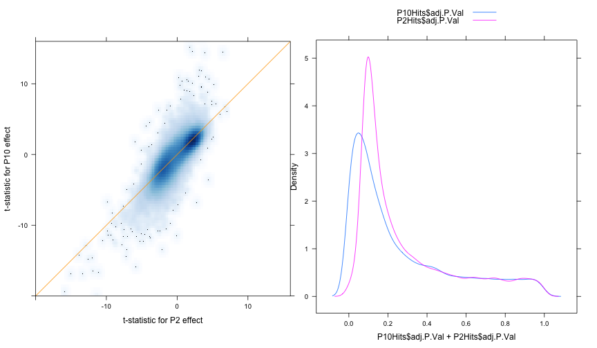

```r
> print(fig2, position = c(0.48, 0, 1, 1))
```

If you require a BH adjusted p-value less than 1e-03, how many hits do you get for P2? How many for P10? How much overlap is there?

```r
> cutoff <- 1e-03
> foo <- data.frame(P2 = P2Hits$adj.P.Val < cutoff,
+                   P10 = P10Hits$adj.P.Val < cutoff)
> addmargins(with(foo, table(P2, P10)))
```

```
       P10
P2      FALSE  TRUE   Sum
  FALSE 29201   695 29896
  TRUE      1    52    53
  Sum   29202   747 29949
```

There are 53 hits for P2, 747 for P10, with an overlap of 52.

#### Perform inference for some contrasts

Let's try to distinguish genes that have stable expression at the last three developmental stages (P6, P10, and 4_weeks) from those that do not.

```r
> colnames(wtDesMat)
```

```
[1] "(Intercept)"     "devStageP2"      "devStageP6"      "devStageP10"
[5] "devStage4_weeks"
```

```r
> (cont.matrix <- makeContrasts(P10VsP6 = devStageP10 - devStageP6,
+                               fourweeksVsP10 = devStage4_weeks - devStageP10,
+                               levels = wtDesMat))
```

```
                 Contrasts
Levels            P10VsP6 fourweeksVsP10
  Intercept             0              0
  devStageP2            0              0
  devStageP6           -1              0
  devStageP10           1             -1
  devStage4_weeks       0              1
```

```r
> wtFitCont <- contrasts.fit(wtFit, cont.matrix)
> wtEbFitCont <- eBayes(wtFitCont)
> topTable(wtEbFitCont)
```

```
             P10VsP6 fourweeksVsP10 AveExpr     F   P.Value adj.P.Val
1440645_at    0.7247          3.041   6.528 632.7 2.224e-17 6.662e-13
1416041_at   -0.1470          4.782   9.383 302.4 1.473e-14 2.206e-10
1425222_x_at  0.7492          3.983   7.028 235.4 1.300e-13 1.297e-09
1424852_at    0.3442          3.405   7.454 225.1 1.910e-13 1.430e-09
1420726_x_at  0.1732          3.551   7.190 203.5 4.555e-13 2.640e-09
1451635_at    0.8260          4.172   8.319 200.0 5.289e-13 2.640e-09
1429394_at   -0.0980          2.410   7.848 167.5 2.416e-12 1.034e-08
1455447_at   -0.9765         -1.800   9.973 153.5 5.063e-12 1.896e-08
1429791_at    0.2480          1.658   8.026 145.7 7.877e-12 2.621e-08
1422612_at    0.4837          3.426   8.833 142.2 9.676e-12 2.840e-08
```

The top hits are probes where there is big change from P6 to P10, from P10 to 4_weeks, or both. Plot the data from the top 4 hits.

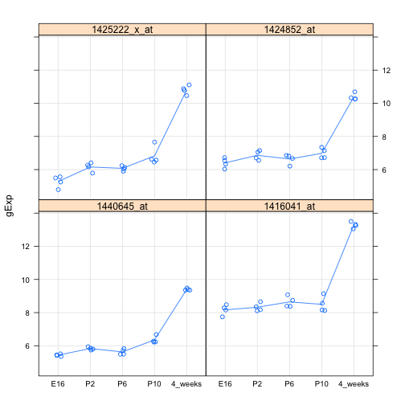

```r
> foo <- topTable(wtEbFitCont)
> stripplotIt(prepareData(rownames(foo)[1:4]))
```

Use decideTests() to adjust the p-values for both contrasts globally, i.e. all together and then threshhold them at a cutoff of 1e-04.

```r
> cutoff <- 1e-04
> wtResCont <- decideTests(wtEbFitCont, p.value = cutoff, method = "global")
> summary(wtResCont)
```

```
   P10VsP6 fourweeksVsP10
-1       4              8
0    29945          29895
1        0             46
```

- There are 4 probes that go down from P6 to P10 and no hits going the other way.
- There are 8 probes that go down from P10 to 4_weeks and 46 going the other way.

Here are the 4 that decline from P6 to P10.

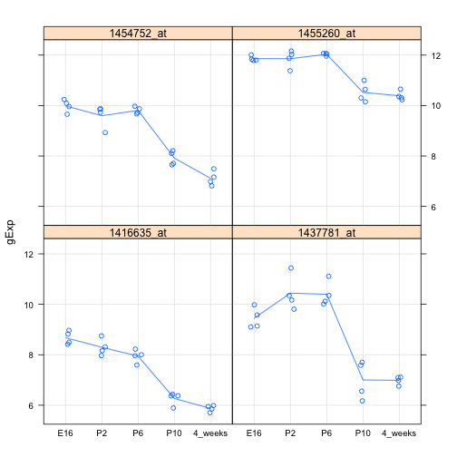

```r
> hits1 <- rownames(prDat)[which(wtResCont[, "P10VsP6"] < 0)]
> stripplotIt(prepareData(hits1))
```

```r
> hits2 <- rownames(prDat)[which(wtResCont[, "fourweeksVsP10"] < 0)]
```

Is there any overlap between these probes?

```r
> intersect(hits1, hits2)
```

```
character(0)
```

If I revisit this workflow but make the p-value cutoff less stringent, maybe I can find the gene expression profile I'm looking for.

```r
> cutoff <- 0.01
> nHits <- 8
> wtResCont <- decideTests(wtEbFitCont, p.value = cutoff, method = "global")
> summary(wtResCont)
```

```
   P10VsP6 fourweeksVsP10
-1      40             49
0    29897          29636
1       12            264
```

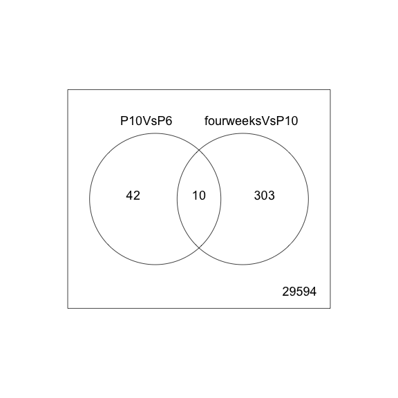

```r
> vennDiagram(wtResCont)
```

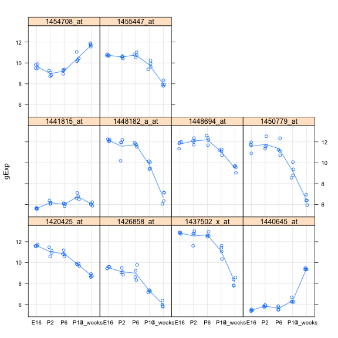

```r
> hits5 <- rownames(prDat)[which(wtResCont[, "P10VsP6"] != 0 &
+                                  wtResCont[, "fourweeksVsP10"] != 0)]
> stripplotIt(prepareData(hits5))
```

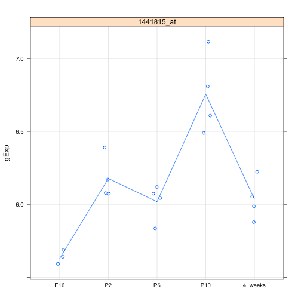

```r
> hits6 <- rownames(prDat)[which(wtResCont[, "P10VsP6"] > 0 &
+                                  wtResCont[, "fourweeksVsP10"] < 0)]
> stripplotIt(prepareData(hits6))
```

### Take-home exercise

See if you can find one or more probes that have some expression changes up to P6 and then hold steady all the way to 4_weeks.

> It searches for probes which have gene expression changes both from E16 to P2 and from P2 to P6, and at the same time, no changes from either P6 to P10, or P10 to 4_weeks. The cut-off p-value is set at 1e-02.

```r
> colnames(wtDesMat)
```

```
[1] "(Intercept)"     "devStageP2"      "devStageP6"      "devStageP10"
[5] "devStage4_weeks"
```

```r
> (cont.matrix <- makeContrasts(P2VsE16 = devStageP2,
+                               P6VsP2 = devStageP6 - devStageP2,
+                               P10VsP6 = devStageP10 - devStageP6,
+                               fourweeksVsP10 = devStage4_weeks - devStageP10,
+                               levels = wtDesMat))
```

```
                 Contrasts
Levels            P2VsE16 P6VsP2 P10VsP6 fourweeksVsP10
  Intercept             0      0       0              0
  devStageP2            1     -1       0              0
  devStageP6            0      1      -1              0
  devStageP10           0      0       1             -1
  devStage4_weeks       0      0       0              1
```

```r
> wtFitCont <- contrasts.fit(wtFit, cont.matrix)
> wtEbFitCont <- eBayes(wtFitCont)
> cutoff <- 1e-02
> wtResCont <- decideTests(wtEbFitCont, p.value = cutoff, method = "global")
> summary(wtResCont)
```

```
   P2VsE16 P6VsP2 P10VsP6 fourweeksVsP10
-1     149      2      38             44
0    29795  29930   29900          29675
1        5     17      11            230
```

```r
> hits <- rownames(wtDat)[which(wtResCont[, "P2VsE16"] != 0 &
+                                 wtResCont[, "P6VsP2"] != 0 &
+                                 wtResCont[, "P10VsP6"] == 0 &
+                                 wtResCont[, "fourweeksVsP10"] == 0)]
```

Here are the probes I got:

```r
> hits
```

```
[1] "1419740_at" "1421821_at" "1450723_at"
```

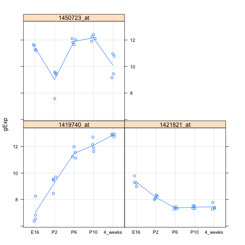

```r
> stripplotIt((prepareData(hits)))
```